# Health Insurance Forecasting with Regression Algorithms and Machine Learning Methodology

### Table of Contents

- Introduction
- Dependencies
- The Data
- Exploratory Data Analysis
- Pre-Processing
- Modeling
- Model Performance Analysis
- Model Deployment API via Fast API

# Introduction

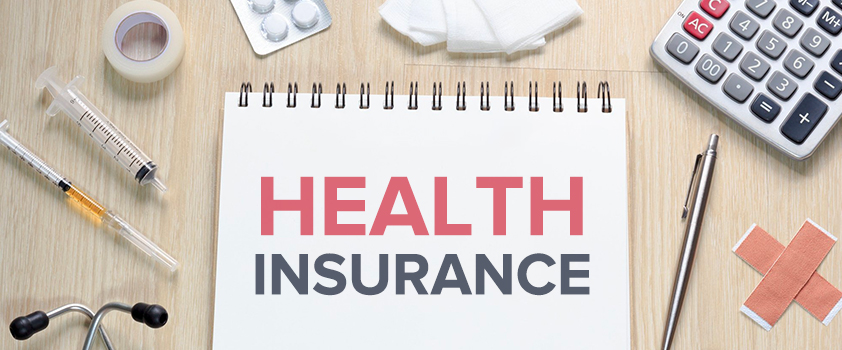

In order to make money, insurance companies need to collect more in premiums than it spends on medical care to its beneficiaries. Every insurer makes a significant portion of its revenue by underwriting, which is basically charging a fee (called a premium) for taking on financial risk.

A great deal of time and money is invested to employ statistical and mathematical models to evaluate and mitigate the financial risk involved in different scenarios.

Therefore it is in the interest in the insurer to have data on insurance premiums and have models they can rely on to create the best contract. In this project I will use demographic data.

# Dependencies

```python
#exploratory data analysis and visualization
import pandas as pd
import numpy as np
import matplotlib.pyplot as plt
import seaborn as sns
# import plotly.express as px #provides a flexible and powerful API for interactive data visualizations
# import plotly.graph_objects as go  #Allows detailed customization of plotly figures
# import plotly.io as pio #Rendering for plotly figures to compatiable formats (notebook,html)




#models
from sklearn.model_selection import train_test_split
from sklearn.linear_model import LinearRegression
from sklearn.linear_model import Ridge
from sklearn.linear_model import Lasso
from sklearn.linear_model import ElasticNet
from sklearn.tree import DecisionTreeRegressor
from sklearn.ensemble import RandomForestRegressor
from sklearn.ensemble import AdaBoostRegressor
from xgboost import XGBRegressor


#transformations
from sklearn.preprocessing import MinMaxScaler
from sklearn.preprocessing import StandardScaler
from sklearn.preprocessing import RobustScaler
from sklearn.preprocessing import PolynomialFeatures

#automate transformations process
from sklearn.pipeline import Pipeline

#regression metrics
from sklearn.metrics import mean_absolute_error
from sklearn.metrics import mean_squared_error



#Cross Validation and HyperParameter Tuning
import optuna
from sklearn.model_selection import cross_validate
from sklearn.model_selection import cross_val_score
from sklearn.model_selection import GridSearchCV
from sklearn.model_selection import RandomizedSearchCV

#Deployment stuff/ Backend Graphics stuff/ Logistics
# import flask
import warnings
# from dash import Dash, dcc, html
# from IPython.display import HTML, Markdown, display
# import base64
# import io
```

# The Data

The data comes from the book **Machine Learning with R by Brett Lantz** published by Packt Publishing. It is a simulated data set using hypothetical medical expenses. The data was gleamed from demographic statistics from the *US Census Bureau* for patients in the United States.

```python
pd.set_option('display.max_columns',None)
data = pd.read_csv('insurance.csv')
data.head(5)
```

|  | age | sex | bmi | children | smoker | region | expenses |
| --- | --- | --- | --- | --- | --- | --- | --- |
| 0 | 19 | female | 27.9 | 0 | yes | southwest | 16884.92 |
| 1 | 18 | male | 33.8 | 1 | no | southeast | 1725.55 |
| 2 | 28 | male | 33.0 | 3 | no | southeast | 4449.46 |
| 3 | 33 | male | 22.7 | 0 | no | northwest | 21984.47 |
| 4 | 32 | male | 28.9 | 0 | no | northwest | 3866.86 |

```python
data.info(show_counts=True)
```

```
<class 'pandas.core.frame.DataFrame'>
RangeIndex: 1338 entries, 0 to 1337
Data columns (total 7 columns):
 #   Column    Non-Null Count  Dtype
---  ------    --------------  -----
 0   age       1338 non-null   int64
 1   sex       1338 non-null   object
 2   bmi       1338 non-null   float64
 3   children  1338 non-null   int64
 4   smoker    1338 non-null   object
 5   region    1338 non-null   object
 6   expenses  1338 non-null   float64
dtypes: float64(2), int64(2), object(3)
memory usage: 73.3+ KB
```

- Since the data was already processed before being published, there are no missing values and all the data types are correct. There are 1338 observations and 7 variables. Here is a quick rundown of each variable and their context:
- **age**: An integer value indicating the age of the beneficiary.
- **sex**: The policy holders gender.
- **bmi**: The Body Mass index of the beneficiary. It's a measure of how overweight or underweight a person is relative to their height. The formula for BMI (English Formula) is equal to $\frac{Weight (lbs)}{[Height (in)]^2} * 703$
- **children**: The number of children/dependents covered by the insurance plan.
- **smoker**: A categorical variable that contains the classes "yes" or "no" that indicate whether the insured regularly smokes tabacco.
- **region**: The beneficiary's place of residence within the United States divided into four geographic regions: northeast, southeast, southwest, or northwest.
- **expenses**: The medical costs each person charged to the insurance plan for the year.

# Exploratory Data Analysis

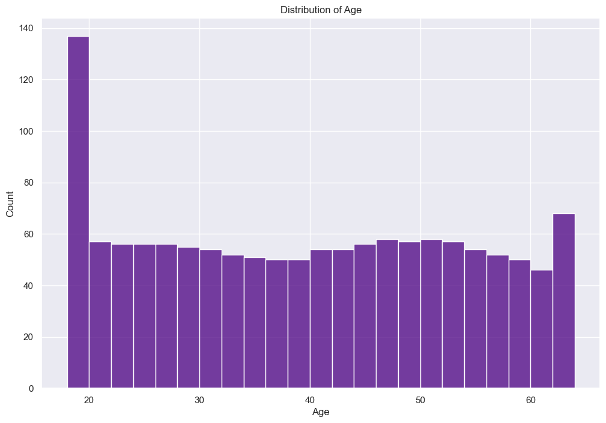

```python
sns.set_theme()
sns.histplot(data['age'],color='indigo',binwidth=2)
sns.set(rc={"figure.figsize": (12, 8)})
plt.title('Distribution of Age')
plt.xlabel('Age')
plt.ylabel('Count')
plt.show()
```

- We immediately observe that most of the age groups are about equally represented. However, the 18-19 age group accounts for more than double of any other age group in this dataset. Why is this the case?
- In the U.S, 18 is the legal age of adulthood (although this can vary from state to state). The Affordable Care Act allows individuals to buy health insurance as young as 18. This is also the age where someone may get their first job and leave their parent or gaurdians plan to enroll in an employers health plan. These resasons may explain the large representation of 18-19 year olds

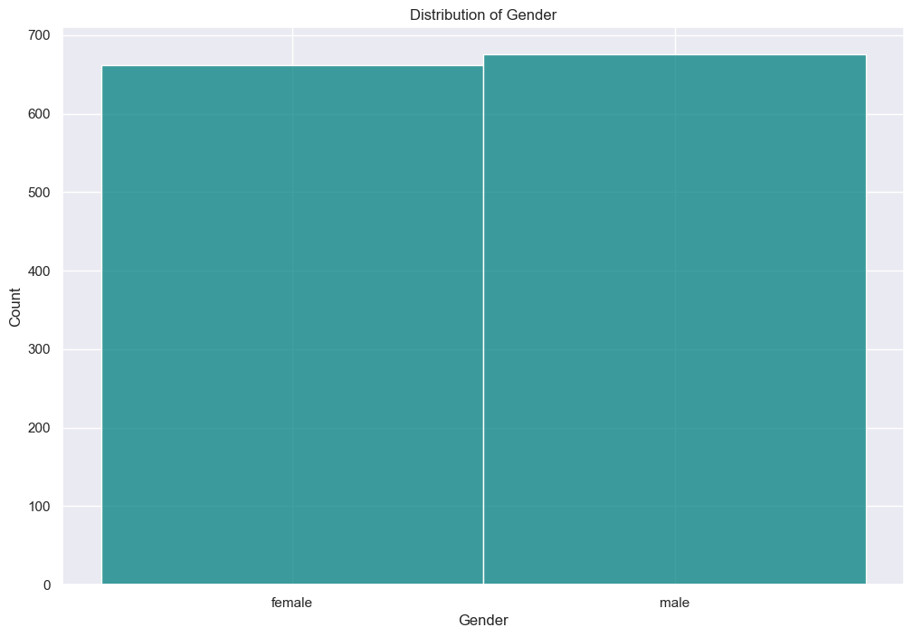

```python
sns.set_theme()
sns.histplot(data['sex'],color='teal')
sns.set(rc={"figure.figsize": (12, 8)})
plt.title('Distribution of Gender')
plt.xlabel('Gender')
plt.ylabel('Count')
plt.show()
```

- 662 of the observations account for Female and 676 observations account for Male. Male and Females are both well accounted for and one group is not too higher or lower than the other. This is well representative.

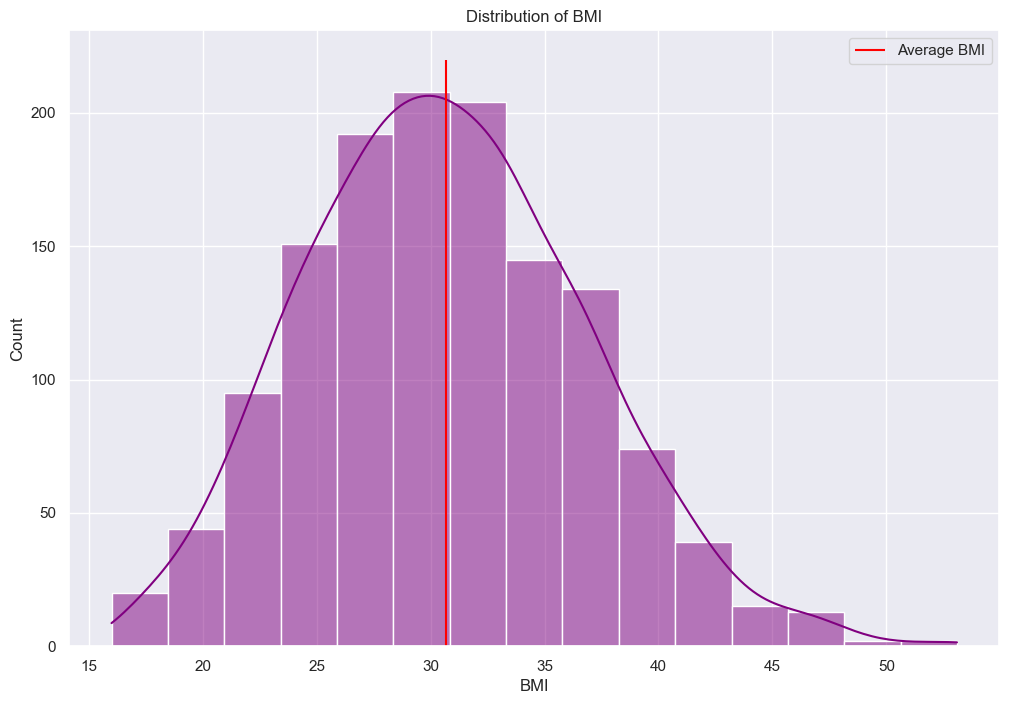

```python
sns.set_theme()
sns.histplot(data['bmi'],bins=15,kde=True,color='purple')
sns.set(rc={"figure.figsize": (12, 8)})
plt.title('Distribution of BMI')
plt.xlabel('BMI')
plt.ylabel('Count')
average_bmi =  np.mean(data['bmi'])
std_bmi = np.std(data['bmi'])
plt.vlines(x = average_bmi,ymin=0,ymax=220,colors='red',label='Average BMI')
plt.legend()
plt.show()
```

- Within this population BMI follows a near Normal Distribution. BMI is a continous variable that is naturally occuring and can be measured. Therefore, Normal-esque behavior is to be expected.
- The average BMI is 30.66 with a standard deviation of 6.09

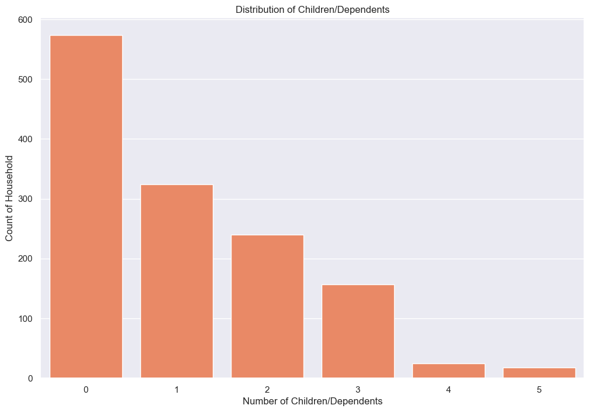

```python
sns.set_theme()
sns.set(rc={"figure.figsize": (12, 8)})
sns.countplot(x=data['children'], color='coral')
plt.title('Distribution of Children/Dependents')
plt.xlabel('Number of Children/Dependents')
plt.ylabel('Count of Household')

plt.show()
```

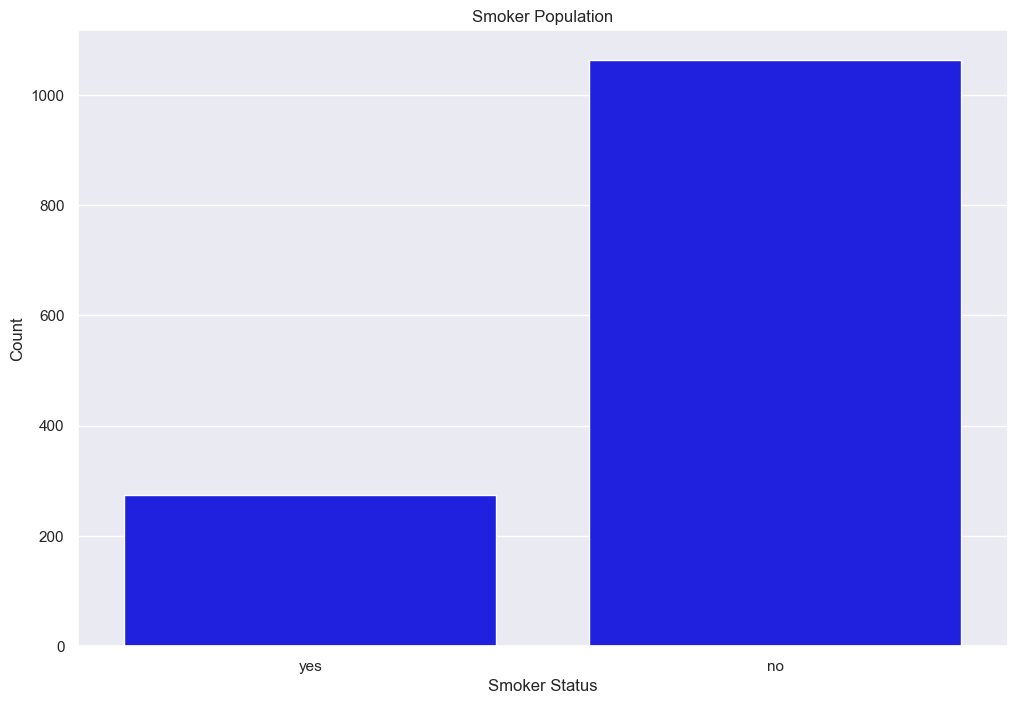

```python
sns.set_theme()
sns.set(rc={"figure.figsize": (12, 8)})
sns.countplot(x=data['smoker'], color='blue')
plt.title('Smoker Population')
plt.xlabel('Smoker Status')
plt.ylabel('Count')

plt.show()
```

- Non-Smokers represent much more of the observations in this dataset.
- There are about 4 times more non-smokers than smokers accounted for tin this dataset.

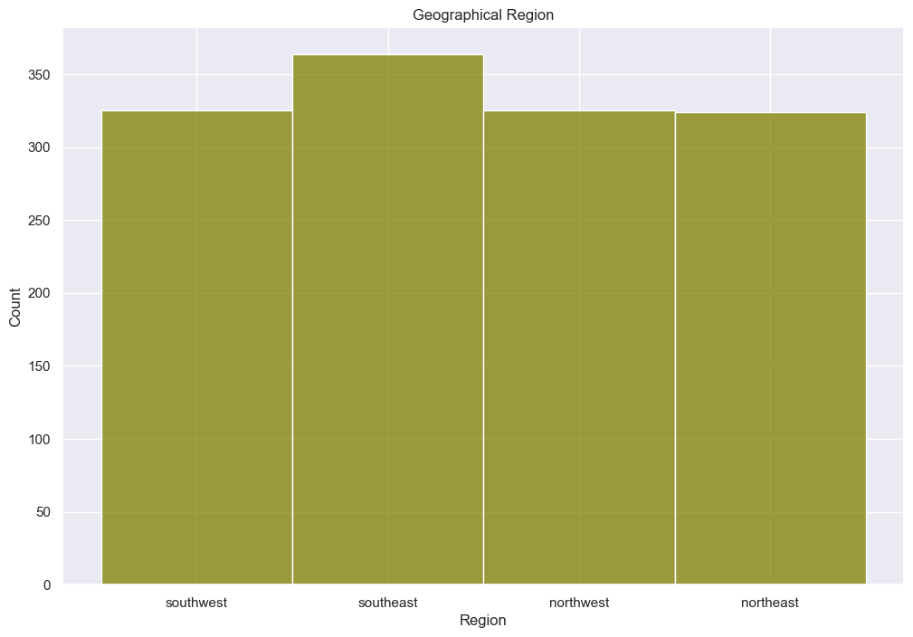

```python
sns.set_theme()
sns.histplot(data['region'],color='olive')
sns.set(rc={"figure.figsize": (12, 8)})
plt.title('Geographical Region')
plt.xlabel('Region')
plt.ylabel('Count')
plt.show()
```

- Each **region** is also well represented with people in the southeast accounting for slightly more with an otherwise equally respresented geography.

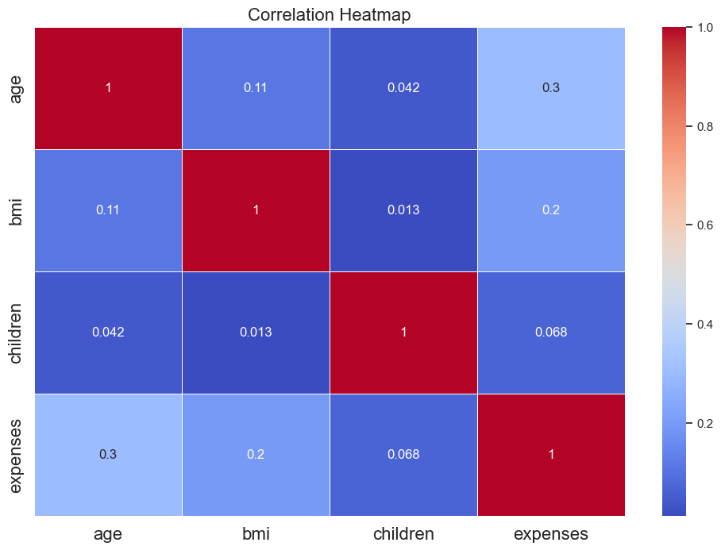

```python
correlations = data.corr(numeric_only=True)
sns.heatmap(correlations, annot=True, cmap='coolwarm', linewidths=.5)
plt.title('Correlation Heatmap',fontsize=16)
plt.xticks(fontsize = 16)
plt.yticks(fontsize = 16)
plt.show()
```

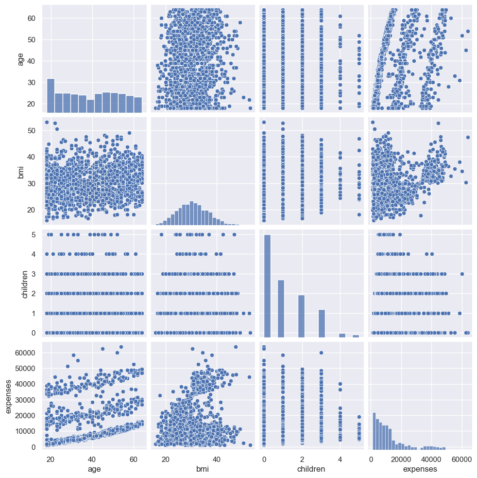

```python
sns.pairplot(data)
plt.show()
```

# Pre-Processing

- The label we are interested in predicting is **expenses** as we want to understand medical premiums with respect to the othe lifestyle factors. This information may be of interest for an underwriter.
- We first need to pre-process the data. We need to get our variables into a format where it can be predicted with a Machine Learning model. Numerical features need to be Scaled and Categorical features need to be Encoded.

```python
data.head()
```

|  | age | sex | bmi | children | smoker | region | expenses |
| --- | --- | --- | --- | --- | --- | --- | --- |
| 0 | 19 | female | 27.9 | 0 | yes | southwest | 16884.92 |
| 1 | 18 | male | 33.8 | 1 | no | southeast | 1725.55 |
| 2 | 28 | male | 33.0 | 3 | no | southeast | 4449.46 |
| 3 | 33 | male | 22.7 | 0 | no | northwest | 21984.47 |
| 4 | 32 | male | 28.9 | 0 | no | northwest | 3866.86 |

- **sex**, **smoker**, and **region** are all nominal categorical variables. This means they naturally don't have an inherent order to them, and we can rest assured knowing that encoding these variables won't result in a relationship that does not actually exist between them.
- **age**, **bmi**, and **children** are numerical variables that are of different scales and units. Because of this we want to scale these variables.
- The following function does the entire pre-processing step:
  - Takes in the dataframe
  - Seperates out the matrix $X$ and label vector $y$
  - Performs a train/validation/test split
  - Scales the numeric variables, encodes the categorical variables
  - Re-assigns them into the respective variable names

```python
def preprocess_data(data):
    # Splitting the data
    X = data.drop('expenses', axis=1)
    y = data['expenses']

    # Splitting into train (70%), validation (15%), and test (15%)
    X_train, X_other, y_train, y_other = train_test_split(X, y, test_size=0.3, random_state=1931)
    X_val, X_test, y_val, y_test = train_test_split(X_other, y_other, test_size=0.5, random_state=1931)

    # Initialize scaler for numeric columns
    standard_scaler = StandardScaler()

    # Processing numeric columns (float or int)
    numeric_cols = X_train.select_dtypes(include=['float64', 'int64']).columns.tolist()

    # Fit scaler on the training set and transform train, val, and test sets
    X_train[numeric_cols] = standard_scaler.fit_transform(X_train[numeric_cols])
    X_val[numeric_cols] = standard_scaler.transform(X_val[numeric_cols])
    X_test[numeric_cols] = standard_scaler.transform(X_test[numeric_cols])

    # Handling categorical columns (object/string) via One-Hot Encoding
    categorical_cols = X_train.select_dtypes(include=['object']).columns.tolist()

    # Apply One-Hot Encoding on categorical columns, but only for those columns
    X_train_encoded = pd.get_dummies(X_train, columns=categorical_cols, drop_first=True)
    X_val_encoded = pd.get_dummies(X_val, columns=categorical_cols, drop_first=True)
    X_test_encoded = pd.get_dummies(X_test, columns=categorical_cols, drop_first=True)

    # Align columns (to ensure the same columns in validation/test as in train)
    X_val_encoded = X_val_encoded.reindex(columns=X_train_encoded.columns, fill_value=0)
    X_test_encoded = X_test_encoded.reindex(columns=X_train_encoded.columns, fill_value=0)

    # Reassign the processed sets back to the original variable names
    X_train = X_train_encoded
    X_val = X_val_encoded
    X_test = X_test_encoded


    #convert bool columns into 0/1
    bool_cols = X_train.select_dtypes(include = ['bool']).columns.tolist()
    X_train[bool_cols] = X_train[bool_cols].astype(int)
    X_val[bool_cols] = X_val[bool_cols].astype(int)
    X_test[bool_cols] = X_test[bool_cols].astype(int)

    return X_train, X_val, X_test, y_train, y_val, y_test
```

```python
X_train, X_val, X_test, y_train, y_val, y_test = preprocess_data(data)
```

```python
X_train.head()
```

|  | age | bmi | children | sex_male | smoker_yes | region_northwest | region_southeast | region_southwest |
| --- | --- | --- | --- | --- | --- | --- | --- | --- |
| 920 | 1.580039 | -0.925368 | -0.909388 | 0 | 0 | 0 | 0 | 1 |
| 667 | 0.035332 | 0.360373 | 0.762886 | 0 | 1 | 1 | 0 | 0 |
| 445 | 0.386402 | 0.409825 | -0.909388 | 0 | 0 | 0 | 0 | 1 |
| 121 | -1.509375 | -1.123175 | -0.909388 | 1 | 0 | 0 | 0 | 0 |
| 483 | 0.807686 | 1.464792 | -0.073251 | 0 | 0 | 0 | 0 | 1 |

```python
X_val.head()
```

|  | age | bmi | children | sex_male | smoker_yes | region_northwest | region_southeast | region_southwest |
| --- | --- | --- | --- | --- | --- | --- | --- | --- |
| 631 | -1.088091 | -0.216562 | -0.909388 | 1 | 0 | 0 | 0 | 1 |
| 954 | -0.385952 | -0.463820 | -0.073251 | 1 | 1 | 1 | 0 | 0 |
| 593 | -1.298733 | -1.436368 | -0.073251 | 0 | 1 | 0 | 0 | 0 |
| 964 | 0.877900 | 1.019728 | 0.762886 | 1 | 0 | 1 | 0 | 0 |
| 316 | 0.737472 | 0.261470 | -0.909388 | 1 | 0 | 1 | 0 | 0 |

```python
X_test.head()
```

|  | age | bmi | children | sex_male | smoker_yes | region_northwest | region_southeast | region_southwest |
| --- | --- | --- | --- | --- | --- | --- | --- | --- |
| 125 | -0.947663 | -0.298981 | -0.909388 | 0 | 0 | 0 | 0 | 0 |
| 736 | -0.175310 | 1.283470 | -0.909388 | 0 | 1 | 0 | 1 | 0 |
| 518 | -0.315738 | 0.063664 | -0.073251 | 0 | 0 | 0 | 0 | 1 |
| 1094 | 0.737472 | 0.508728 | 2.435160 | 0 | 0 | 0 | 0 | 1 |
| 99 | -0.105096 | -1.864949 | -0.909388 | 1 | 1 | 0 | 0 | 1 |

# Modeling

- Now that our dataset has been processed, we can start modeling. Since the target variable is continuous, this is a Regression Problem.

```python
#Instantiate the models
#By default I'm setting a learning rate of 100 for all models(Will hyperparameter tune later)
def fit_predict_models(X_train,y_train,X_val):
    model_linearregression = LinearRegression()
    model_ridge = Ridge(alpha = 100)
    model_lasso = Lasso(alpha = 100)
    model_elasticnet = ElasticNet(alpha=100,l1_ratio=.5)
    model_decisiontree = DecisionTreeRegressor()
    model_randomforest = RandomForestRegressor(n_estimators=100,max_depth=10,min_samples_split=5,random_state=1931)
    model_adaboost = AdaBoostRegressor(learning_rate=100,random_state=1931)
    model_xgboost = XGBRegressor (learning_rate=1,random_state=1931)

    #Fit for all models
    model_linearregression.fit(X_train,y_train)
    model_ridge.fit(X_train,y_train)
    model_lasso.fit(X_train,y_train)
    model_elasticnet.fit(X_train,y_train)
    model_decisiontree.fit(X_train,y_train)
    model_randomforest.fit(X_train,y_train)
    model_adaboost.fit(X_train,y_train)
    model_xgboost.fit(X_train,y_train)

    #Create prediction arrays off of the label vector (VALIDATION SET)
    predictions_linearregression = model_linearregression.predict(X_val)
    predictions_ridge = model_ridge.predict(X_val)
    predictions_lasso = model_lasso.predict(X_val)
    predictions_elasticnet = model_elasticnet.predict(X_val)
    predictions_decisiontree = model_decisiontree.predict(X_val)
    predictions_randomforest = model_randomforest.predict(X_val)
    predictions_adaboost = model_adaboost.predict(X_val)
    predictions_xgboost = model_xgboost.predict(X_val)

    #Create arrays of RMSE for each model
    #Note: I am checking against the VALIDATION SET right now.
    RMSE_linearregression = np.sqrt(mean_squared_error(y_val,predictions_linearregression))
    RMSE_ridge = np.sqrt(mean_squared_error(y_val,predictions_ridge))
    RMSE_lasso = np.sqrt(mean_squared_error(y_val,predictions_lasso))
    RMSE_elasticnet = np.sqrt(mean_squared_error(y_val,predictions_elasticnet))
    RMSE_decisiontree = np.sqrt(mean_squared_error(y_val,predictions_decisiontree))
    RMSE_randomforest = np.sqrt(mean_squared_error(y_val,predictions_randomforest))
    RMSE_adaboost = np.sqrt(mean_squared_error(y_val,predictions_adaboost))
    RMSE_xgboost = np.sqrt(mean_squared_error(y_val,predictions_xgboost))

    #Create Viz

    Errors = {'LinearRegression':RMSE_linearregression,'Ridge':RMSE_ridge,'Lasso':RMSE_lasso,
             'ElasticNet':RMSE_elasticnet,'DecisionTree':RMSE_decisiontree,'RandomForest':RMSE_randomforest,
             'AdaBoost': RMSE_adaboost, 'XGBoost':RMSE_xgboost}
    Keys = list(Errors.keys())
    Values = list(Errors.values())

    sns.set(style = "whitegrid")
    plt.figure(figsize=(5,7))
    plt.xlabel('Model')
    plt.ylabel('RMSE').get_rotation()
    plt.bar(Keys,Values)
    plt.xticks(rotation = 45)
    plt.grid(True)
    plt.show()

    #Print Errors
    print(Errors)
```

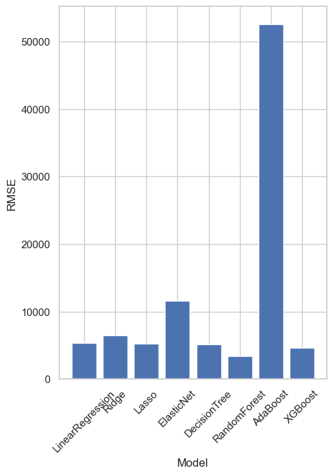

```
{'LinearRegression': 5368.564736203896, 'Ridge': 6542.11625634214, 'Lasso': 5272.242543150266, 'ElasticNet': 11575.247012726362, 'DecisionTree': 5195.439019245343, 'RandomForest': 3408.287068761971, 'AdaBoost': 52550.44122083935, 'XGBoost': 4653.710803374125}
```

```python
fit_predict_models(X_train,y_train,X_val)
```

- With respect to baseline settings, Random Forest and XGBoost performed the best. Let's explore these models further and see if we can tune hyperparameters to get better performance.

# Model Performance Analysis

### Analyze Random Forest Further

- To get an idea of how our model is performing with respect with to bias/variance tradeoff (overfitting vs underfitting) we can look at Learning Curves. Learning Curves allow us to analyze a models error metric as complexity increases. In the case of Random Forest, some of the hyperparamters of interest would be:
- **n_estimators**: The number of trees in the forest.
- **max_depth**: The maximum depth of the tree. If None, then nodes are expanded until all leaves are pure or until all leaves contain less than min_samples_split samples.
- **min_samples_split**: The minimum number of samples required to split an internal node.
- **min_samples_leaf**: The minimum number of samples required to be at a leaf node. A split point at any depth will only be considered if it leaves at least min_samples_leaf training samples in each of the left and right branches. This may have the effect of smoothing the model, especially in regression.

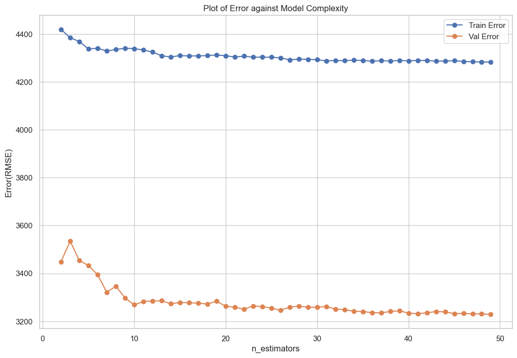

```python
#n_estimators learning curve

train_rmse_errors = []
val_rmse_errors = []
X_train, X_val, X_test, y_train, y_val, y_test = preprocess_data(data)

for i in range(2,50):
    model_randomforest = RandomForestRegressor(bootstrap = True, max_depth = 10, min_samples_leaf = 10, min_samples_split= 2, n_estimators= i,random_state=1931)
    model_randomforest.fit(X_train,y_train)

    train_predictions = model_randomforest.predict(X_train)
    val_predictions = model_randomforest.predict(X_val)

    train_rmse = np.sqrt(mean_squared_error(y_train,train_predictions))
    val_rmse = np.sqrt(mean_squared_error(y_val,val_predictions))

    train_rmse_errors.append(train_rmse)
    val_rmse_errors.append(val_rmse)



plt.plot(range(2,50),train_rmse_errors, label = 'Train Error', marker = 'o')
plt.plot(range(2,50),val_rmse_errors, label = 'Val Error', marker = 'o')
plt.xlabel('n_estimators')
plt.ylabel('Error(RMSE)')
plt.title('Plot of Error against Model Complexity')
plt.legend()
plt.show()
```

- The model performed better on the validation than the training set. High training loss, Low validation loss. Model is underfit. It can also mean this specific validation split does not contain enough information.
- The large gap between the curves also indicates potential issues with generalization. A large gap suggests that the model is not able to generalize its learnings from the training data

```python
#gridsearch for Random Forest
warnings.filterwarnings('ignore')
X_train, X_val, X_test, y_train, y_val, y_test = preprocess_data(data)


param_grid = {
    'n_estimators': [10,50,100,150,200],  # Number of trees
    'max_depth': [3,5,15,25, None],  # Depth of each tree
    'min_samples_split': [1,2, 5,10,15],  # Min samples to split a node
    'min_samples_leaf': [1,3,6,8,10],    # Min samples at a leaf node
    'max_features': ['sqrt','log2'], # Number of features to consider for best split
    'bootstrap': [True, False]        # Whether to bootstrap samples
}



# Setup GridSearchCV
grid_search = GridSearchCV(estimator=model_randomforest,
                           param_grid=param_grid,
                           cv=5,
                           scoring='neg_mean_squared_error',
                           n_jobs=-1,
                           verbose=0) #setting verbose to zero, to make notebook less unsightly

# Fit model
grid_search.fit(X_train, y_train)

# Best hyperparameters
best_params = grid_search.best_params_
print(f"Best Hyperparameters: {best_params}")

# Evaluate on val set
best_randomforest = grid_search.best_estimator_
y_pred = best_randomforest.predict(X_val)
```

```
Best Hyperparameters: {'bootstrap': False, 'max_depth': 25, 'max_features': 'log2', 'min_samples_leaf': 3, 'min_samples_split': 10, 'n_estimators': 100}
```

```python
rmse = np.sqrt(mean_squared_error(y_val, y_pred))
print(f'Root Mean Squared Error: {rmse}')
print(f'Best Params: {best_params}')
```

```
Root Mean Squared Error: 3321.6040555884942
Best Params: {'bootstrap': False, 'max_depth': 25, 'max_features': 'log2', 'min_samples_leaf': 3, 'min_samples_split': 10, 'n_estimators': 100}
```

Using the validation set, the GridSearchCV with CrossValidation K=5 found the best hyperparameters for Random Forest to be:

**max_depth**: 25

**min_samples_leaf**: 3

**min_samples_split**: 10

**n_estimators**: 100

**bootstrap**: False

**max_features**: 'log2'

```python
#final Random Forest
X_train, X_val, X_test, y_train, y_val, y_test = preprocess_data(data)

model_randomforest = RandomForestRegressor(max_depth=25,
                                           min_samples_leaf=3,
                                           min_samples_split=10,
                                           n_estimators = 100,
                                           bootstrap=False,
                                           max_features= 'log2',
                                           random_state=1931)

model_randomforest.fit(X_train,y_train)

#final predictionns on the test set to get "the final word" on how we can expect the model to perform
predictions_randomforest = model_randomforest.predict(X_test)

test_rmse = np.sqrt(mean_squared_error(y_test,predictions_randomforest))

print(f'On average, we can expect the Random Forest to predict the expenses label with an error of: ${test_rmse}')
```

```
On average, we can expect the Random Forest to predict the expenses label with an error of: $4340.456031202441
```

### Analyze XGBoost Regressor Further

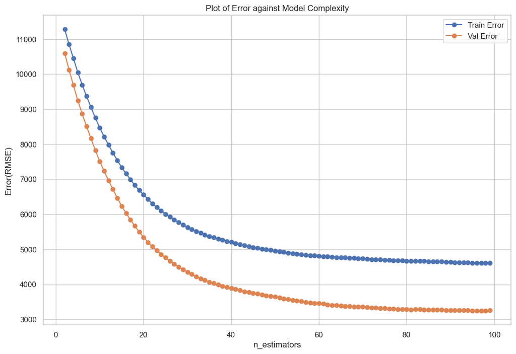

```python
train_rmse_errors = []
val_rmse_errors = []
X_train, X_val, X_test, y_train, y_val, y_test = preprocess_data(data)

for i in range(2,100):
    model_xgboost = XGBRegressor(
        objective='reg:squarederror',
        n_estimators=i,
        learning_rate=0.05,
        max_depth=2,
        subsample=0.5,
        colsample_bytree=1,
        random_state=1931
    )
    model_xgboost.fit(X_train,y_train)

    train_predictions = model_xgboost.predict(X_train)
    val_predictions = model_xgboost.predict(X_val)

    train_rmse = np.sqrt(mean_squared_error(y_train,train_predictions))
    val_rmse = np.sqrt(mean_squared_error(y_val,val_predictions))

    train_rmse_errors.append(train_rmse)
    val_rmse_errors.append(val_rmse)



plt.plot(range(2,100),train_rmse_errors, label = 'Train Error', marker = 'o')
plt.plot(range(2,100),val_rmse_errors, label = 'Val Error', marker = 'o')
plt.xlabel('n_estimators')
plt.ylabel('Error(RMSE)')
plt.title('Plot of Error against Model Complexity')
plt.legend()
plt.show()
```

```python
#gridsearch for XGBoost
warnings.filterwarnings('ignore')
X_train, X_val, X_test, y_train, y_val, y_test = preprocess_data(data)

param_grid = {
    'objective':['reg:squarederror'],  # Number of trees
    'n_estimators': [15,35,50,100,150],  # Number of boosting rounds (trees)
    'learning_rate': [0.05,0.1,0.2,0.5],  # Step size shrinkage
    'max_depth': [2,3,6,8],    # Maximum depth of each tree
    'subsample': [0.5,0.7], # Fraction of features used per tree
    'colsample_bytree': [0.5,0.7,1],
}

# Setup GridSearchCV
grid_search = GridSearchCV(estimator=model_xgboost,
                           param_grid=param_grid,
                           cv=5,
                           scoring='neg_mean_squared_error',
                           n_jobs=-1,
                           verbose=0)

# Fit model
grid_search.fit(X_train, y_train)

# Best hyperparameters
best_params = grid_search.best_params_
print(f"Best Hyperparameters: {best_params}")

# Evaluate on val set
best_xgboost = grid_search.best_estimator_
y_pred = best_xgboost.predict(X_val)
```

```
Best Hyperparameters: {'colsample_bytree': 1, 'learning_rate': 0.05, 'max_depth': 2, 'n_estimators': 100, 'objective': 'reg:squarederror', 'subsample': 0.5}
```

Using the validation set, the GridSearchCV with CrossValidation K=5 found the best hyperparameters for XGBoost to be:

**colsample_bytree**: 1

**learning_rate**: 0.05

**max_depth**: 2

**n_estimators**: 100

**subsample**: 0.5

```python
X_train, X_val, X_test, y_train, y_val, y_test = preprocess_data(data)

model_xgboost = XGBRegressor(
        objective='reg:squarederror',
        n_estimators=100,
        learning_rate=0.05,
        max_depth=2,
        subsample=0.5,
        colsample_bytree=1,
        random_state=1931)

model_xgboost.fit(X_train,y_train)


#final predictions on the test set to get "the final word" on how we can expect the model to perform
predictions_xgboost = model_xgboost.predict(X_test)

test_rmse = np.sqrt(mean_squared_error(y_test,predictions_xgboost))

print(f'On average, we can expect XGBoost Regressor to predict the expenses label with an error of: ${test_rmse:.2f}')
```

```
On average, we can expect XGBoost Regressor to predict the expenses label with an error of: $4210.26
```

- Although both models were quite close in performance, The XGBoost model performed better than the Random Forest model. I will move forward with the XGBoost to the deployment stage.
- I will train a final XGBoost model with the best hyperparameters as given by the gridsearch. The final model will be trained on all available data before deployment.

```python
#train the final model on all available data
X_train, X_val, X_test, y_train, y_val, y_test = preprocess_data(data)


final_model_xgboost = XGBRegressor(
        objective='reg:squarederror',
        n_estimators=100,
        learning_rate=0.05,
        max_depth=2,
        subsample=0.5,
        colsample_bytree=1,
        random_state=1931)

X_final = pd.concat([X_train,X_test,X_val])
y_final = pd.concat([y_train,y_test,y_val])


final_model_xgboost.fit(X_final,y_final)
```

```
XGBRegressor(base_score=None, booster=None, callbacks=None,
             colsample_bylevel=None, colsample_bynode=None, colsample_bytree=1,
             device=None, early_stopping_rounds=None, enable_categorical=False,
             eval_metric=None, feature_types=None, gamma=None, grow_policy=None,
             importance_type=None, interaction_constraints=None,
             learning_rate=0.05, max_bin=None, max_cat_threshold=None,
             max_cat_to_onehot=None, max_delta_step=None, max_depth=2,
             max_leaves=None, min_child_weight=None, missing=nan,
             monotone_constraints=None, multi_strategy=None, n_estimators=100,
             n_jobs=None, num_parallel_tree=None, random_state=1931, ...)
```

# Model Deployment via Fast API and Docker (work in progress)

```python
%%capture
!jupyter nbconvert --to html 'Health Insurance Forecasting With Regression Algorithms and Machine Learning Methodology.ipynb' --output index;
```